# Comments for MEDB 5502, Module 01

## Instructor Information

- Steve Simon, PhD
  - Email: simons@umkc.edu
  - Phone Number: 816-235-6617
- Suman Sahil
  - Email: sumans@umkc.edu
  - Phone number: 816-235-1812

## Instructor Response Time

We prefer contact by email, but will respond to telephone calls or messages on Canvas. We are teaching multiple classes, so please remind us which class you are in.

We will check our email daily, except on weekends. If you have not received a response withing 48 hours (excluding weekends), please feel free to follow up with a reminder email.

You can attend weekly review sessions and ask questions about anything. Times and Zoom link information are available on Canvas. You can also schedule individual sessions, either via Zoom or face-to-face.

## MEDB 5502, Applied Biostatistics II, 3 credit hours

- Section 0001 (11785): Synchronous zoom
- Section 0002 (12496): Asynchronous
- Section 0003 (15108): In person attendance

## Introduction

Clinical research has been critical for the development of new medications and treatments. Now, clinical research carries an increasingly important role as it contributes to critical issues facing our health care system. In order for clinical research to address these issues, appropriate methods for data processing and analysis must be conducted. The Department of Biomedical and Health Informatics Biostatistics sequence has been designed to provide students with the applied knowledge and skills they will need in order to contribute to the creation, analysis, and understanding of data generated by clinical and patient care studies.

## Prerequisites

Only Graduate level students (students holding a BS or BA or higher degree) are permitted to register for this course. You must have completed MEDB 5501 (Applied Biostatistics I) or a comparable class.

## Course Objectives

The Biostatistics sequence (MEDB5501 and 5502) will provide students with an understanding of basic and more advanced concepts in statistics as applied to health sciences. The objective of this course, MEDB 5502, is to examine more complex statistical models than those presented in MEDB 5501. In particular, you will see how to handle multiple variables simultaneously. This course will also provide a firm foundationfor those students planning to take MEDB 5503 or other advanced and specialized statistical analysis classes.

## Student Learning Objectives

At the end of this course, students will be able to:

- Understand and implement the statistical concepts behind diagnostic testing
- Manage and analyze data sets in order to test research hypotheses
- Estimate and summarize data characteristics in order to determine appropriate statistical analysis methods
- Apply statistical methods for analyzing continuous data, specifically analysis of variance, analysis of covariance, multivariate analysis of variance, linear regression, and multiple regression
- Apply statistical methods for analyzing categorical data, such as logistic regression, survival analysis, and other nonparametric statistical methods
- Understanding the theory of propensity score generation as well as its application to research design
- Understand the principles of Evidence Based Medicine
- Apply the statistical knowledge gained in this course in a practical manner
- Undertake further study of statistics if desired

## Course Framework

There is a long tradition of data management and statistical analysis as applied to research on various health topics from multicenter drug development trials to clinical outcomes studies to small sample clinical research. Understanding the statistical analysis methods required to conduct valid research is critical as clinical research plays an increasingly significant role in the evolution of our health care system. Results from clinical research studies contribute not only to the development of new drugs, devices and treatments but also to the determination of the best treatments for health care providers to offer patients (best practice). The readings, assignments, quizzes, semester project, and midterm and final exams in this course are designed to be relevant to the application of the knowledge and skills gained in MEDB5502 to clinical, biomedical, and public health research.

## Course Expectations, Course Policies, Requirements and Standards for Student Coursework and Student Behavior

You are expected to do your homework independently. You can seek help from your instructors, from colleagues, or from the Internet to help decode an error message that you don’t understand. You can adapt code that you find on the Internet. We recommend that you acknowledge the source for that code in the comments of your program, but this is not required.

## Evaluation and Grading

Students will be required to post messages on the Canvas discussion boards, take brief quizzes on Canvas, and submit homework assignments in PDF format on Canvas. Your work is due on the specified date. We need to keep the class on the same time schedule for a variety of reasons. If illness, family issues, work responsibilities, or other commitments prevent you from completing on time, please contact me before the due date. Late submission without prior notice will receive a one point deduction. If you find yourself repeatedly falling behind on quizzes and assignments, it would be good to set up a meeting to discuss this.

This course is grade Credit/No Credit (Pass/Fail). Students who complete at least 80% of the regular coursework and successfully complete the final project will receive credit for the course.

## Point values for all assignments

- Discussion boards, 3 points
- Homework, 20 points
- Quizzes, 1 point per question
- Midterm presentation, 20 points
- Midterm report, 20 points
- Final exam, 60 points

There may be minor changes to amount of points assigned to the final exam. There may be an additional report due at the end of the semester.

Quizzes are graded automatically by Canvas. Grades for discussion boards, homework, and your final project will be completed within 14 days of the due date.

## E-mail

You must use a UMKC e-mail account for correspondence in this class. The instructor will not be responsible for the receipt of e-mails that are sent to locations other than those ending with “umkc.edu”.

## Canvas

All students are required to be registered with Canvas in order to have access to course-related material that is posted on that site. All Announcements will be posted on Canvas and the student will also receive that Announcement via their UMKC email. All students will be responsible for knowledge and /or completion of any posted Announcement directives. UMKC Resources & Policy Statements

Academic Calendar: Students are encouraged to review important [add, drop or withdraw dates](http://www.umkc.edu/registrar/acal.asp)

## Academic Honesty

The Board of Curators of the University of Missouri recognizes that academic honesty is essential for the intellectual life of the University. Faculty members have a special obligation to expect high standards of academic honesty in all student work. Students have a special obligation to adhere to such standards. Academic dishonesty, including cheating, plagiarism or sabotage, is adjudicated through the University of Missouri Student Conduct Code and Rules of Procedures in Student Conduct Matters.

Conduct for which students are subject to sanctions includes academic dishonesty, such as cheating, plagiarism, or sabotage. In the event misconduct is confirmed, the students will receive 0 points on the exam or assignment. If academic dishonesty is admitted or confirmed by evidence the faculty are required to report the incident to the Assistant Dean for Graduate Studies, who will meet with the faculty member and student to review the event and then determine whether it should be further referred to the Dean of the School of Graduate Studies.

Students enrolled in this course assume an obligation to behave in a manner compatible with the University’s function as an educational institution as described in the University Collected Rules and Regulations Chapter 200 Student Conduct, section 200.010 Standard of Conduct. Conduct for which students are subject to sanctions includes academic dishonesty, such as cheating, plagiarism, or sabotage. Conduct for which students are subject to sanctions are outlined as follows:

The term cheating includes but is not limited to: (i) use of any unauthorized assistance in taking quizzes, tests, or examinations; (ii) dependence upon the aid of sources beyond those authorized by the instructor in writing papers, preparing reports, solving problems, or carrying out other assignments; (iii) acquisition or possession without permission of tests or other academic material belonging to a member of the University faculty or staff; or (iv) knowingly providing any unauthorized assistance to another student on quizzes, tests, or examinations.

The term plagiarism includes, but is not limited to: (i) use by paraphrase or direct quotation of the published or unpublished work of another person without fully and properly crediting the author with footnotes, citations or bibliographical reference; (ii) unacknowledged use of materials prepared by another person or agency engaged in the selling of term papers or other academic materials; or (iii) unacknowledged use of original work/material that has been produced through collaboration with others without release in writing from collaborators.

The term sabotage includes, but is not limited to, the unauthorized interference with, modification of, or destruction of the work or intellectual property of another member of the University community.

To ensure academic integrity and prevent plagiarism, UMKC has purchased the Internet-based Turn It In. This site allows faculty and students to submit papers online to examine a paper’s originality. The site compares submitted papers with several proprietary algorithm databases to check for plagiarism. The course director reserves the right to have student assignments reviewed on Turnitin.com in this course. Submissions will have all identifying student information (name, student ID number etc.) removed from the submission to ensure that student’s rights are protected.

## Academic Inquiry, Course Discussion and Privacy

University of Missouri System Executive Order No. 38 lays out principles regarding the sanctity of classroom discussions at the university. The policy is described fully in Section 200.015 of the Collected Rules and Regulations. In this class, students may make audio or video recordings of course activity with permission from the instructor. However, the redistribution of any audio or video recordings of statements or comments from the course to individuals who are not students in the course is prohibited without the express permission of instructor and of any students who are recorded, including those recordings prepared by the instructor. Students found to have violated this policy are subject to discipline in accordance with provisions of Section 200.020 of the Collected Rules and Regulations of the University of Missouri pertaining to student conduct matters.

## Statement on Privacy of Student Records

All educational records are protected by FERPA (Family Education Rights and Privacy Act) as described in the University Collected Rules and Regulations, section 180.020 Student Records. If you have questions or would like more information refer to [this regulation and its its implementation at UMKC](https://www.umsystem.edu/ums/rules/collected_rules/information/ch180/180.020_student_records).

## Statement on Expectations Regarding Student Conduct

In order to maintain a proper learning environment within the classroom, it is important for all students enrolled in this course to treat both the faculty and their peers with courtesy, civility and respect. Conduct for which students are subject to sanctions includes academic dishonesty, such as cheating, plagiarism, or sabotage. For more information regarding this regulation visit the [UM System rules on student conduct](https://www.umsystem.edu/ums/rules/collected_rules/programs/ch200). Students whose behavior is deemed disruptive by their instructor may be told to leave the classroom for the remainder of the session.

## Counseling and Health Services Available at UMKC

UMKC students may experience many challenges in their lives while attending college – stress, depression, suicidality, trauma, relationship issues, health concerns, etc. As your professor I care about your success and well-being, and want to make you aware of some helpful resources on campus.

The [UMKC Counseling Center](https://www.umkc.edu/counselingcenter), located at 4825 Troost in Room 206, offers a wide range of supportive services to students. Appointments can be made by calling 816.235.1635. [UMKC Student Health and Wellness](https://info.umkc.edu/studenthealth/), located at 4825 Troost in Room 115, offers a full range of health care and promotion services. Appointments can be scheduled online or by calling 816.235.6133. The [Mind-Body Connection](https://www.umkc.edu/wellness/resources/mental-health/mindbody-connection.html) is located in the Atterbury Student Success Center in Room 112 and offers a variety of stress-reduction services.

## Disability Support Services

To obtain disability related accommodations and/or auxiliary aids, students with disabilities must contact the Office of Services for Students with Disabilities (OSSD) as soon as possible. To contact OSSD, call (816) 235-5696. Once verified, OSSD will notify the course instructor and outline the accommodation and/or auxiliary aids to be provided. For more information, go to the [UMKC page on disability resources](https://www.umkc.edu/disability/).

## English Proficiency Statement

Students who encounter difficulty in their courses because of the English proficiency of their instructors should speak directly with their instructors. If additional assistance is needed, students may contact the UMKC Help Line at 816-235-2222 for assistance.

## Grade Appeal Policy

Students are responsible for meeting the standards of academic performance established for each course in which they are enrolled. The establishment of the criteria for grades and the evaluation of student academic performance are the responsibilities of the instructor.

The University grade appeal procedure is available only for the review of allegedly capricious grading and not for review of the instructor’s evaluation of the student’s academic performance. Capricious grading, as that term is used here, comprises any of the following:

- The assignment of a grade to a particular student on some basis other than the performance in the course;
- The assignment of a grade to a particular student according to more exacting or demanding standards than were applied to other students in the course; (Note: Additional or different grading criteria may be applied to graduate students enrolled for graduate credit in 300- and 400-level courses.)
- The assignment of a grade by a substantial departure from the instructor’s previously announced standards.

Students who have concerns about this course should first consult with the specific instructor with whom there is a problem. If the issues are not satisfactorily resolved the student should contact the course director. In the event a student would like to appeal a course grade they must follow the [School of Medicine procedure for grade appeal for graduate courses](https://med.umkc.edu/docs/coe/COE-Policy-Manual-Guidelines.pdf).

## Discrimination Grievance Procedures for Students

Discrimination Grievance Procedures for Students can be found in [Chapter 390 of the collected rules and regulations](https://www.umsystem.edu/ums/rules/collected_rules/grievance/ch390).

The course faculty is committed to creating and maintaining a supportive learning environment. If at any time you find yourself in an environment that does not support learning, it is best to first contact the course faculty. If faculty members are unable to resolve the situation for you, you may contact

- the Chair of the Department,
- the Associate Dean for Student Affairs,
  - Dr. Brenda Rogers, SOM Rm M4-207, rogersbr@umkc.edu, (816) 235-1782, or
- the Office of Diversity & Community Partnership,
  - Sam Turner, SOM Rm. M1-109, (816) 235-1780.

## Statement of Human Rights

The Board of Curators and UMKC are committed to the policy of equal opportunity, regardless of race, color, religion, sex, sexual orientation, national origin, age, disability and status as a Vietnam era veteran. Commitment to the policy is mentored by the Division of Diversity, Access & Equity, but it is the responsibility of the entire university community to provide equal opportunity through relevant practices, initiatives and programs.

## Title IX

Under the University of Missouri’s Title IX policy, discrimination, violence and harassment based on sex, gender, and gender identity are subject to the same kinds of accountability and support applied to offenses based on other protected characteristics such as race, color, ethnic or national origin, sexual orientation, religion, age, ancestry, disability, military status, and veteran status. If you or someone you know has been harassed or assaulted, you can find the appropriate resources

- by visiting [UMKC’s Title IX Office webpage](https://info.umkc.edu/title9/)
- or contacting UMKC’s Title IX Coordinator,
  - Sybil B. Wyatt, JD, EdD, MS (816.235.6910 or wyattsb@umkc.edu).

While most UMKC employees are required to report any known or suspected violation of Title IX, students may seek confidential guidance from the following campus locations:

- UMKC Counseling Service, Volker Campus
  - 4825 Troost Ave, Suite 206
  - Kansas City, MO 64110
  - Phone – (816) 235-1635
- UMKC Counseling Service, Health Sciences Campus
  - Health Sciences Building 1418
  - 2464 Charlotte
  - Kansas City, MO 64108
  - Phone – (816) 235-1635
- Student Health and Wellness
  - open Tuesdays, 1-5pm
  - 4825 Troost Ave., Suite 115
  - Kansas City, MO 64110
  - Phone - (816) 235-6133

## Topics

The second in the Applied Biostatistics sequence and is intended for graduate, doctoral, and professional students in the biological, clinical and medical fields, and medical education. Statistical concepts, analysis methods, and research designs commonly used in these fields are included: diagnostic testing, hypothesis testing, power analysis, analysis of variance, analysis of covariance, multivariate analysis of variance, propensity scoring, simple and multiple regression, logistic regression, and survival analysis. Familiarity with basic statistics and the statistical techniques presented in Applied Biostatistics I is required. Statistical analyses involved in this course will be performed primarily using the SPSS statistical analysis package. The course will also cover the interpretation, presentation and the write up of analytical results and graphs.

Listed below is a rough outline of the topics covered in the class. There may be some minor changes to the order of topics. In addition, some topics may be added or removed. Please refer to the Canvas site for the most current description of course topics.

## Module 01

- Simple linear regression (Sections 9.1 through 9.7)
- One factor analysis of variance (Chapter 12)

Many of you are taking this class as a continuation of Applied Biostatistics I (MEDB 5501) last semester or perhaps earlier. A few of you may have taken a slightly different class. In any case, a brief review might prove helpful. Much of this class will build on and extend material on simple linear regression and one factor analysis of variance. This week, you will review those methods.

In addition, you will learn about the general structure of this class.

## Module 02

- Multiple linear regression (Sections 9.8 through 9.11)
- Mediation analysis (Section 11.4)

The “multiple” in multiple linear regression means multiple independent variables. Two big issues arise in multiple linear regression. First, the correlation among independent variables can complicate the analysis and interpretation of the results. Second, multiple linear regression allows you to informally examine mediation.

## Module 03

- Analysis of covariance (Chapter 13)

A covariate is a variable that is not of direct interest to the research hypothesis, but one that you still need to account for to provide a credible analysis. In this module, you will learn how to adjust for a covariate, especially one that is imbalanced between the treatment/exposure and the control group.

## Module 04

- Multifactor analysis of variance (Chapter 14)
- Moderator analysis (Section 11.3)

The lesson for this week covers a multi-factorial ANOVA. Specifically we will be discussing the 2-way Independent ANOVA. This is the simplest and the most commonly used and encountered multi-factorial Independent AVOVA. As you will see in the lesson, the theory (mathematical and procedural) of the 2-way Independent ANOVA can easily be extrapolated to even more complex ANOVA’s.

## Module 05

- Factor analysis (Chapter 18)

Factor analysis and its cousin, principal components analysis, provide a way to simply a large dataset through variable reduction. These methods produce linear combinations of variables that can account for most of the variation among the original variables. This will often let you sidestep the informal requirement of 15 observations for each independent variable and also simplify graphical comparisons.

## Module 06

- Logistic regression (Chapter 20)

When your outcome variable is categorical with only two levels (e.g, a binary variable), you can use logistic regression to predict that outcome. Logistic regression is very flexible. You can use continuous predictor variables or categorical variables. You can examine interactions among your predictor variables. You can look at risk adjustments: the effect of one predictor variable on the outcome while holding the other variable constant.

## Module 07

- Diagnostic testing (not in Field)

A diagnostic test is a rapid, convenient, and/or inexpensive method to assess whether your patient has a particular disease. You evaluate this diagnostic test using a gold standard. The gold standard may be slower, less convenient, or more expensive than the diagnostic test, but it provides a definitive indication of disease. Your test is good if it minimizes the number of false positive (diagnostic test is positive, but your patient is healthy) and the number of false negatives (diagnostic test is negative, but your patient has the disease). In this module, you will learn how to compute the sensitivity, specificity, and likelihood ratios for a diagnostic test and apply them in practice.

## Module 08

- Survival analysis (not in Field)

Survival analysis, more accurately called time-to-event analysis provides a way to evaluate the time required for an event to occur. A unique feathre of these analyses is that some patients never experience the event, at least not while part of the research study. The Kaplan-Meier curve is a graphical way of displaying the survival probabilities. The log rank test provides a simple approach for testing whether two treatments have different survival probabilities. A more complex model, Cox regression, can handle handle continuous predictor variables, risk adjustment, and interactions.

## Module 09

- Meta-analysis (not in Field)

Meta-analysis is the quantitative summary of results from multiple independent research studies. If you produce a meta-analysis, you need to address concerns about heterogeneity, study quality, publication bias, and interpretability. Although there are many controversies and disagreements about how to properly conduct a meta-analysis, the approach is helpful in identifying research gaps and deciding when to close the book on further research.

## Module 10

- The dark side of data science (not in Field)

Large scale models (big data) using powerful new algorithms (data science) have the potential for great benefit but also can produce great harms. In this module, you will look at two competing philosophical perspectives: one which presumes that quantitative methods are objective and one that believes that these methods reflect the attitudes and perspectives of the researchers themselves. If you adopt the latter perspective, you can better understand how seemingly objective statistical models can incorporate biases and prejudices. This is becoming a greater problem because recent data science models make it difficult to spot overt biases. These models also amplify any prejudices because they are often deployed at a very large scale. An additional problem with recent models is their ability to reveal private and sensitive information. Several case studies will show serious problems with data science in a range of areas.

## Module 11

- Hierarchical models (Chapter 16)

Hierarchical models allow you to work with data collected in clusters, such as family units or clinics. Observations within a cluster are often positively correlated. You can account for this correlation by including a random effect in your statistical model. An example using measurements from litters shows how hierarchical models allow you to make comparisons within and between clusters.

## Module 12

- Longitudinal models (Chapters 15, 16, 21)

Longitudinal models characterize patients measured at multiple time points. Longitudinal models characterize multiple sources of variation, captured in the random intercepts and random slopes models.

## Module 13

- Bayesian analysis (scattered throughout Field)

Bayesian data analysis offers an alternative to classical hypothesis testing. In a Bayesian model, you specify a prior distribution that represents information from previous studies and/or a researcher’s subjective opinions.

## Module 14

- To be announced

## File details

This file was written by Steve Simon on 2025-01-19, with major sections written by an anonymous source at UMKC. As far as I know, there are no copyright restrictions on the use of this material.

## Linear regression interpretation of a straight line

- The slope represents the estimated average change in Y when X increases by one unit.
- The intercept represents the estimated average value of Y when X equals zero.
- Terminology
  - X is the independent or predictor variable
  - Y is the dependent or outcome variable

## Simple regression example with interpretation, 1

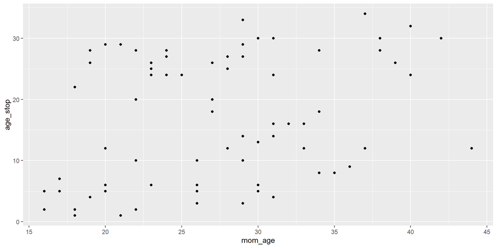

## Simple regression example with interpretation, 2

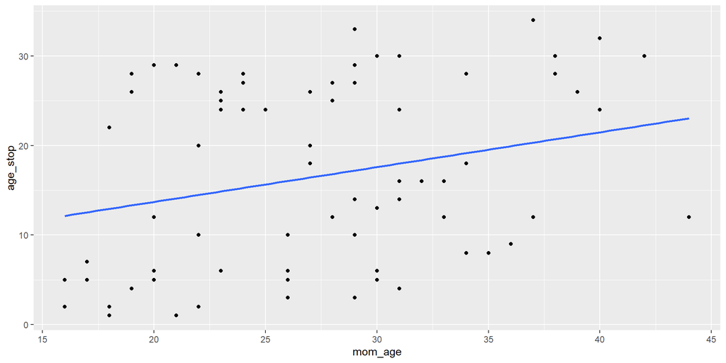

## Simple regression example with interpretation, 3

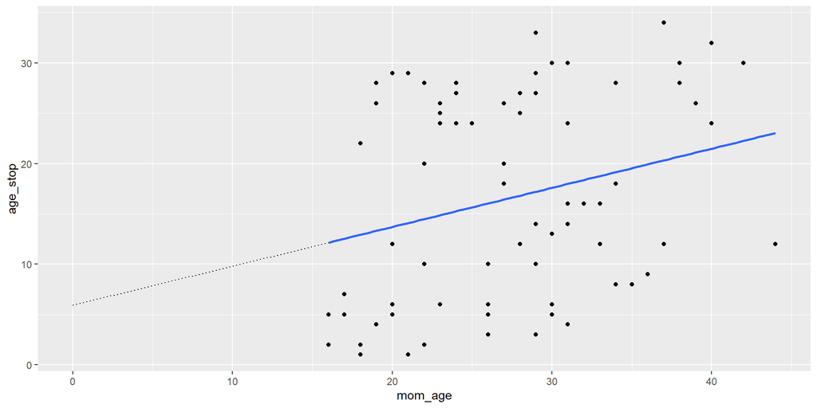

## Simple regression example with interpretation

```
Call:
lm(formula = age_stop ~ mom_age, data = bf)

Coefficients:
(Intercept)      mom_age
      5.920        0.389
```

## Predicted values, 1

- How long would you expect a 20 year old mom to breast feed?

```
# A tibble: 5 × 2
  mom_age age_stop
    <dbl>    <dbl>
1      20        5
2      20       29
3      20        6
4      20       NA
5      20       12
```

## Predicted values, 2

- For an existing value in the data, $X_i$
  - $\hat{Y}_i=b_0+b_1 X_i$
- For a new value of X
  - $\hat{Y}_{new}=b_0+b_1 X_{new}$
  - Do not predict outside the range of X values

## Why predict for a value you already have seen?

- Future Y may differ from previous Y
- $\hat{Y}_i$ is more precise
- Comparison of $\hat{Y}_i$ to existing $Y_i$.

## Predicted values, 3

Predicted age_stop = 5.92 + 0.389*20 = 13.7

```
# A tibble: 1 × 2
  mom_age .fitted
    <dbl>   <dbl>
1      20    13.7
```

## Residuals, 1

- $e_i=Y_i-\hat{Y}_i$
  - Residual = Observed - Predicted
- Very helpful in assessing assumptions

## Residuals, 2

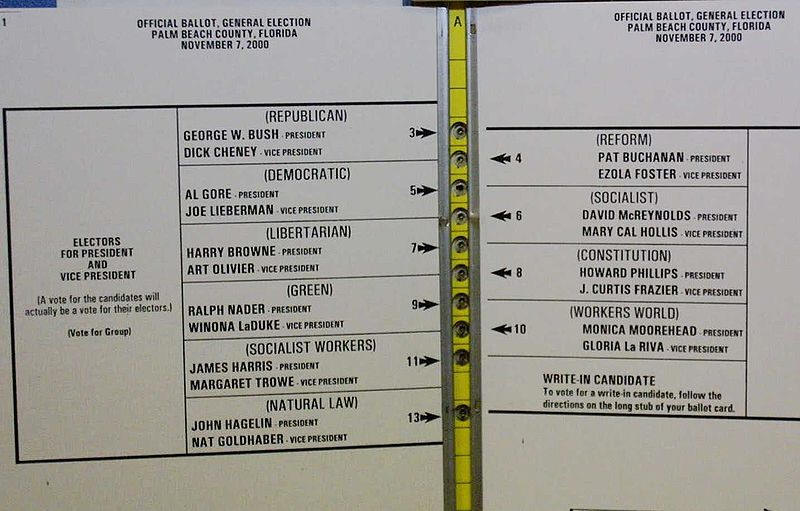

## Residuals, 3

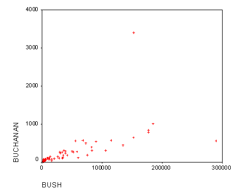

## Residuals, 4

- Votes (Buchanan) = 45.3 +0.0049 * Votes (Bush)
  - The estimated average number of votes for Buchanan increase by 1/200 for every increase of one vote for Bush.

## Residuals, 5

- In Palm Beach County
  - Votes (Bush) = 152,846
  - Predicted Votes (Buchanan) = 797
    - 45 + 0.0049 * 152,846
  - Actual Votes (Buchanan) = 3,407
- Residual = 3,407 - 797 = 2,610

## Residuals, 6

```
# A tibble: 4 × 5
  .rownames mom_age age_stop .fitted .resid
  <chr>       <dbl>    <dbl>   <dbl>  <dbl>
1 8              20        5    13.7  -8.70
2 40             20       29    13.7  15.3
3 44             20        6    13.7  -7.70
4 67             20       12    13.7  -1.70
```